# Tarea 11

Dalia Camacho

# 11-Metropolis

```r
library(ggplot2)
```

Regresamos al ejercicio de IQ de la tarea anterior, en ésta hiciste cálculos para el caso de una sola observación. En este ejercicio consideramos el caso en que observamos una muestra $x=\{x_1,...,x_N\}$, y utilizaremos Metrópolis para obtener una muestra de la distribución posterior.

1. Crea una función $prior$ que reciba los parámetros $\mu$ y $\tau$ que definen tus creencias del parámetro desconocido $\theta$ y devuelva $p(\theta)$, donde $p(\theta)$ tiene distriución $N(\mu, \sigma^2)$

```r
prior <- function(mu, tau){
  function(theta){
    dnorm(theta,mu,tau)
  }
}
```

2. Utiliza la función que acabas de escribir para definir una distribución inicial con parámetros $\mu = 150$ y $\tau = 15$, llámala *mi_prior*.

```r
mu       <- 150
tau      <- 15
mi_prior <- prior(mu=mu, tau=tau)
```

Ya que tenemos la distribución inicial debemos escribir la verosimilitud, en este caso la verosimilitud es:

$$p(x|\theta, \sigma^2)=\frac{1}{(2\pi\sigma^2)^{N/2}}exp\left(-\frac{1}{2\sigma^2}\sum_{j=1}^{N}(x_j-\theta)^2\right)$$
$$=\frac{1}{(2\pi\sigma^2)^{N/2}}exp\left(-\frac{1}{2\sigma^2}\bigg(\sum_{j=1}^{N}x_j^2-2\theta\sum_{j=1}^{N} x_j + N\theta^2 \bigg) \right)$$

Recuerda que estamos suponiendo varianza conocida, supongamos que la desviación estándar es $\sigma=20$.

$$p(x|\theta)=\frac{1}{(2\pi (20^2))^{N/2}}exp\left(-\frac{1}{2 (20^2)}\bigg(\sum_{j=1}^{N}x_j^2-2\theta\sum_{j=1}^{N} x_j + N\theta^2 \bigg) \right)$$

3. Crea una función $likeNorm$ en R que reciba la desviación estándar, la suma de los valores observados $\sum x_i$, la suma de los valores al cuadrado $\sum x_i^2$ y el número de observaciones $N$ la función devolverá la función de verosimilitud (es decir va a regresar una función que depende únicamente de $\theta$).

```r
# sigma: desviación estándar S: sum x_i, S2: sum x_i^2, N: número obs.
likeNorm <- function(sigma, S, S2, N){
  function(theta){
    1/((2*pi*sigma^2)^(N/2))*exp(-1/(2*sigma^2)*(S2 - 2*theta*S + N*theta^2))
  }
}
```

```r
N       <- 100
S       <- 13000
S2      <- 1700000
desvest <- 20
mi_like <- likeNorm(sigma = desvest, S = S, S2 = S2, N = N)
```

5. La distribución posterior no normalizada es simplemente el producto de la inicial y la posterior:

```r
postRelProb <- function(theta){
  mi_like(theta) * mi_prior(theta)
}
```

Utiliza Metropolis para obtener una muestra de valores representativos de la distribución posterior de $\theta$. Para proponer los saltos utiliza una Normal(0, 5).

Definimos la caminata aleatoria a seguir

```r
# Definimos la caminata aleatoria a seguir
caminaAleat <- function(theta){ # theta: valor actual
  salto_prop <- rnorm(1, 0, sd = sqrt(5)) # salto propuesto
  theta_prop <- theta + salto_prop # theta propuesta
  if(theta_prop < 0){ # si el salto implica salir del dominio
    return(theta)
  }
  u <- runif(1)
  p_move <-  min(postRelProb(theta_prop) / postRelProb(theta), 1) # prob mover
  if(p_move  > u){
    return(theta_prop) # aceptar valor propuesto
  }
  else{
    return(theta) # rechazar
  }
}
```

Ahora generamos una simulacioón de la caminata aleatoria

```r
set.seed(5885415)
Nsim     <- 11000
thetavec <- S/N
for(i in 2:Nsim){
  thetavec[i] <- caminaAleat(thetavec[i-1])
}
```

6. Grafica los valores de la cadena para cada paso.

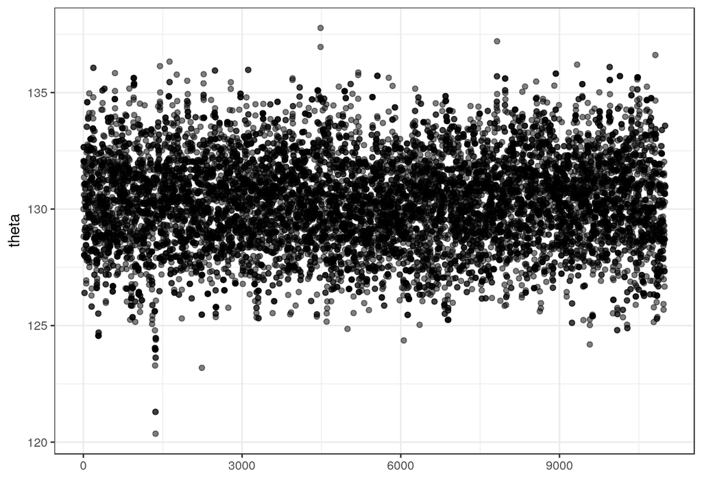

```r
ggplot()+theme_bw()+
  geom_point(aes(1:Nsim, thetavec), alpha=0.5)+
  geom_jitter()+
  xlab("")+
  ylab("theta")
```

7. Elimina los valores correspondientes a la etapa de calentamiento y realiza un histograma de la distribución posterior.

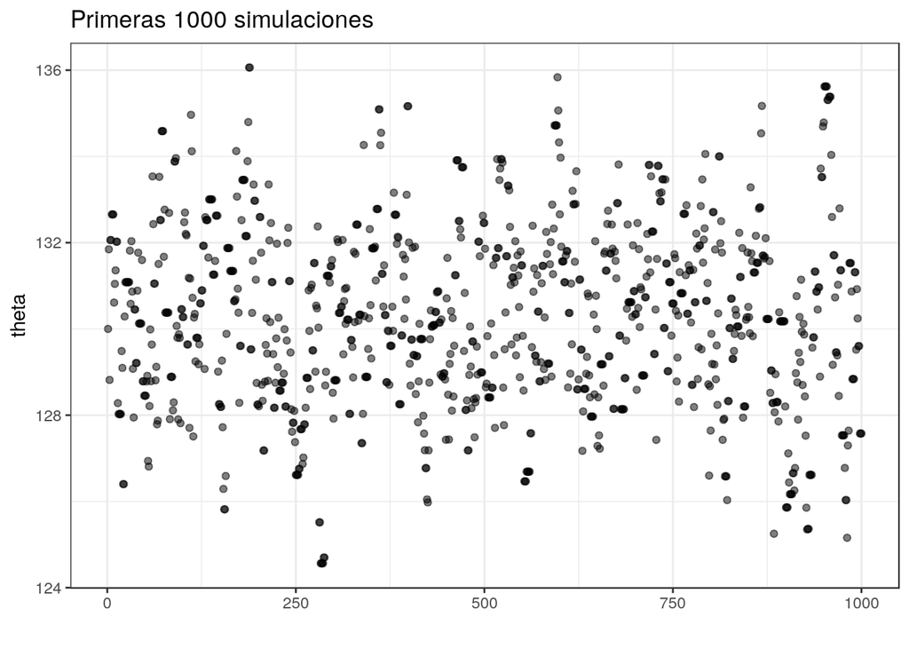

```r
ggplot()+theme_bw()+
  geom_point(aes(1:1000, thetavec[1:1000]), alpha=0.5)+
  xlab("")+
  ylab("theta")+
  ggtitle("Primeras 1000 simulaciones")
```

No se logra distinguir la etapa de calentamiento ni siquiera considerando únicamente los primeros mil pasos. Pero podemos eliminar los primeros 700 pasos por si ese fuera el caso.

```r
theta_sim <- thetavec[701:Nsim]
```

8. Si calcularas la posterior de manera analítica obtendrías que $p(x|\theta)$ es normal con media:
   $$\frac{\sigma^2}{\sigma^2 + N\tau^2}\mu + \frac{N\tau^2}{\sigma^2 + N \tau^2}\overline{x}$$
   y varianza
   $$\frac{\sigma^2 \tau^2}{\sigma^2 + N\tau^2}$$

donde $\bar{x}=1/N\sum_{i=1}^N x_i$ es la media de los valores observados. Realiza simulaciones de la distribución posterior calculada de manera analítica y comparalas con el histograma de los valores generados con Metropolis.

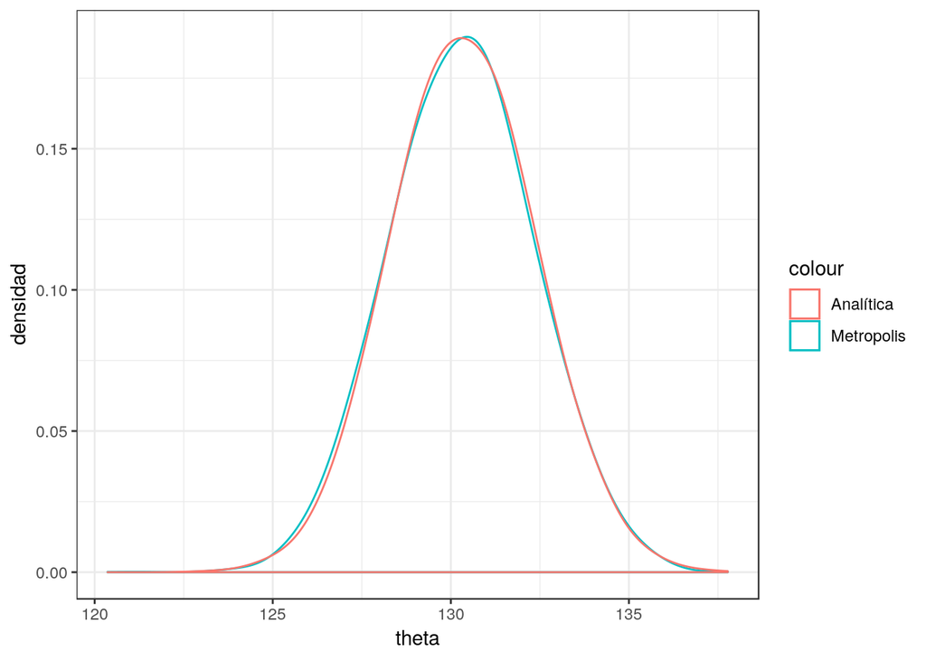

```r
x_bar <- S/N
post_mu      <- desvest^2/(desvest^2+N*tau^2)*mu + N*tau^2/(desvest^2 + N*tau^2)*x_bar
post_desvest <- sqrt(desvest^2*tau^2/(desvest^2+N*tau^2))
Analitic_sim <- rnorm(Nsim, post_mu, post_desvest)

ggplot()+ theme_bw()+
  geom_density(aes(theta_sim, color="Metropolis"), adjust=2)+
  geom_density(aes(Analitic_sim, color="Analítica"), adjust=2)+
  ylab("densidad")+
  xlab("theta")
```

1. ¿Cómo utilizarías los parámetros $\mu, \tau^2$ para describir un escenario donde sabes poco del verdadero valor de la media $\theta$?

Como la a priori refleja la incertidumbre que tengo sobre el verdadero valor de theta elegiría un valor de $\mu$ que considere posible y un valor de $\tau^2$ grande, incluso $\mu=\tau²$ como ocurre en la distribución poisson.